MOSAIC · vignette

# How the results are made

This vignette follows one simulated dataset from raw counts to the figures in the paper, then shows how the real-world and literature-based results are generated. All numbers and figures come from the actual runs. To install and run MOSAIC, see the pipeline guide.

Example setting: taxonomic count data with 450 samples and 301 taxa, condition effect 0.5, batch effect 0.5, and no confounding between batch and condition (odds ratio 1). This is also the baseline simulation for the ablation analyses.

1

## Simulate

We simulate data with MIDASim to resemble a real gut microbiome IBD dataset. Fifty taxa are differentially abundant between the two conditions, and all 301 taxa are affected by batch. To simulate from your own data instead, pass a count table with `--template=` (or set `template` in the simulation config).

```
Rscript benchmark/simulate_scenario.R --out=data --iter=1 \
    --or_l=1 --cond_effect_val_l=0.5 --batch_effect_val_l=0.5
```

| File | Contents |
| --- | --- |
| `ibd_150_count_*.csv` | taxonomic counts, 450 samples × 301 taxa |
| `ibd_150_relab_*.csv` | the same data as relative abundances |
| `ibd_150_meta_*.csv` | batch and condition of each sample |
| `ibd_150_id_cond_*.txt` | the 50 differentially abundant taxa (ground truth) |

2

## Integrate

Each integration strategy is applied to the simulated data. Strategies that can use the condition as a covariate are also run without it, and this version is used for prediction to avoid data leakage.

```
Rscript benchmark/run_sim_methods.R --data=data --out=output_count --iter=1 \
    --datatype=count --methods=combat_seq,limma,MMUPHin,ConQuR,ConQuR_libsize
python3 benchmark/evaluate.py --config config_simulation_scenarios.yml -o 16 -i 1 -d count \
    --data-dir data --output-dir output_count
```

3

## Evaluate one replicate

MOSAIC evaluates each integration strategy and the uncorrected data with the same metrics. The second command repeats the random forest on the data integrated without the condition covariate (leakage-free prediction).

```
python3 benchmark/evaluate.py --config config_simulation_scenarios.yml -o 17 -i 1 -d count \
    --data-dir data --output-dir output_count --eval-dir eval_count
python3 benchmark/evaluate.py --config config_simulation_scenarios.yml -o 17 -i 1 -d count \
    --data-dir data --output-dir output_count --eval-dir eval_count --rerun-rf
```

Results for replicate 1:

| Metric | Uncorrected | ComBat-seq | ConQuR | MMUPHin | Harmony |
| --- | --- | --- | --- | --- | --- |
| Batch PERMANOVA R² (Aitchison) | 0.140 | 0.014 | 0.005 | 0.093 | 0.011 |
| Condition PERMANOVA R² (Aitchison) | 0.042 | 0.054 | 0.052 | 0.045 | 0.078 |
| FDR | 0.846 | 0.000 | 0.111 | 0.083 | 0.840 |
| Sensitivity | 0.080 | 0.440 | 0.480 | 0.440 | 0.080 |
| Shannon ~ batch, p-value | <0.001 | 0.015 | 0.344 | 0.554 | <0.001 |
| Random forest AUROC (leakage-free) | 0.999 | 0.999 | 1.000 | 1.000 | 0.996 |
| Runtime (s) | — | 6.7 | 393 | 0.8 | 0.2 |

- **R²**Variability in microbiome composition explained by batch or condition (PERMANOVA). A successful integration reduces batch R² and maintains condition R².
- **FDR**Differential abundance analysis, compared with the true taxa. FDR should be controlled near 0.05 while sensitivity stays high.
- **p**Association between Shannon diversity and batch. After integration, Shannon diversity should no longer differ between batches.
- **AUC**How well the microbiome predicts the condition (random forest, 5-fold cross-validation). It uses the data integrated without the condition covariate, so strategies that use the condition cannot leak it into the predictors; DEBIAS-M, which is supervised, is fit within each training fold. The AUROC here is close to 1 for every strategy, including the uncorrected data, because a condition effect of 0.5 is large. Figure 2d therefore evaluates prediction on weaker condition effects (0.005–0.1); at 0.005 the AUROC is 0.61 for the uncorrected data and ConQuR and 0.56 for Harmony.

For the first replicate, MOSAIC also saves diagnostic plots. Before integration the two batches separate clearly; after ConQuR they overlap.

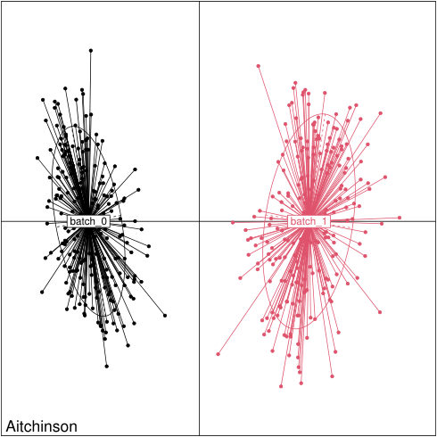

Uncorrected data, colored by batch.

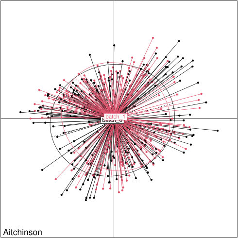

After ConQuR.

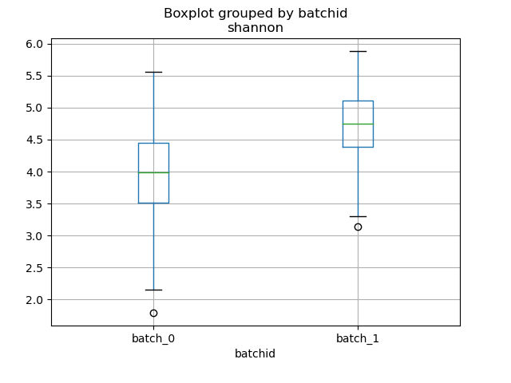

Shannon diversity by batch, uncorrected.

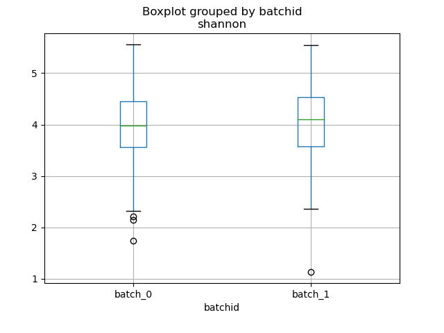

Shannon diversity by batch, after ConQuR.

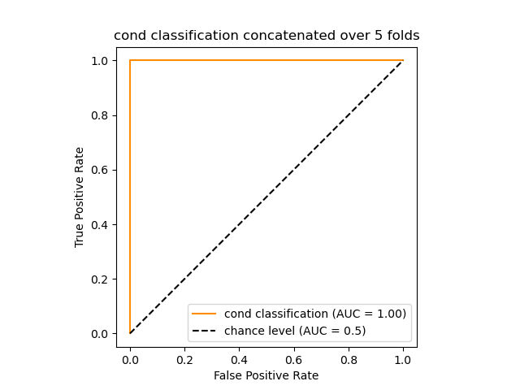

ROC curves, after ConQuR.

4

## Summarize over 1,000 replicates

Steps 1–3 are repeated 1,000 times, and each metric is summarized by its mean and 95% confidence interval. For the Shannon tests, we report the proportion of replicates with p < 0.05.

```
python3 benchmark/aggregate_scenario.py --eval-dir eval_count --n-iter 1000 \
    --values values_count.csv --summary summary_count.csv
```

5

## Figure 2

Panels a–c show the ten combinations of condition and batch effects; the example is the 0.50 / 0.50 setting. Because simulated conditions were highly predictable in all ten settings, panel d uses a sweep of weaker condition effects (0.005–0.1) to better differentiate the integration strategies.

```
python3 benchmark/figures/fig2_style_aggregate.py count no 1 agg     # main grid + condition sweep, 1,000 replicates
python3 benchmark/figures/fig2_style_plots.py agg figures --main      # the complete Figure 2
```

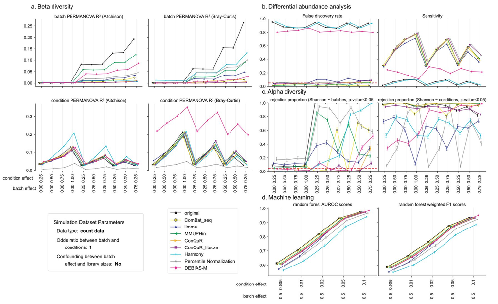

Means and 95% confidence intervals over 1,000 replicates. Red dashed lines mark 0.05. Panel d uses the data integrated without the condition covariate.

6

## Supplemental Figures 1–4

The same evaluation for the other settings: count or relative abundance data, odds ratio 1, 1.25 or 1.5 between batch and condition, and with or without confounding between batch and library size. Aitchison distances are not computed for relative abundance data.

```
for dt in count relab; do for rel in no yes; do for OR in 1 1.25 1.5; do
  python3 benchmark/figures/fig2_style_aggregate.py $dt $rel $OR agg
done; done; done
python3 benchmark/figures/fig2_style_plots.py agg pages                # 12 single-setting pages
python3 benchmark/figures/supp_figs_1to4.py pages figures             # Supp Figs 1-4 (needs PyMuPDF)
```

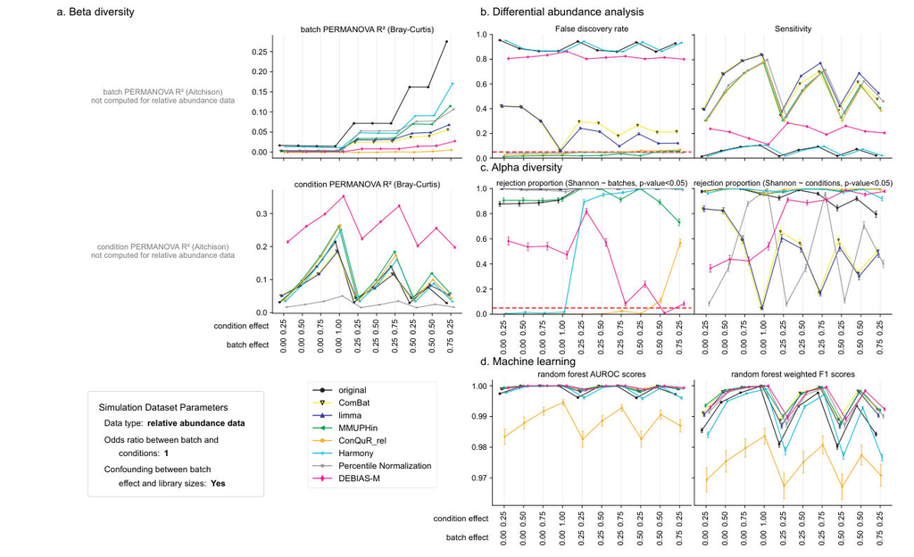

Relative abundance data, batch confounded with library size, odds ratio 1.

7

## Figure 3: ablation analyses

The ablation analyses vary one factor at a time from the baseline: sample size (150), batch effects on half of the taxa, zero inflation (90% zeros), and batch or condition imbalance (10% of samples). Each is summarized over 1,000 replicates and plotted next to the baseline (shaded column).

```
python3 benchmark/figures/ablation_vis.py -i 1000 --root results \
    --setups n150,halftaxa,zeroinf90,batchfrac10,condfrac10 --out ablation     # writes summary_mean_ci.csv
python3 benchmark/figures/fig3_ablation_plots.py ablation/summary_mean_ci.csv figures
```

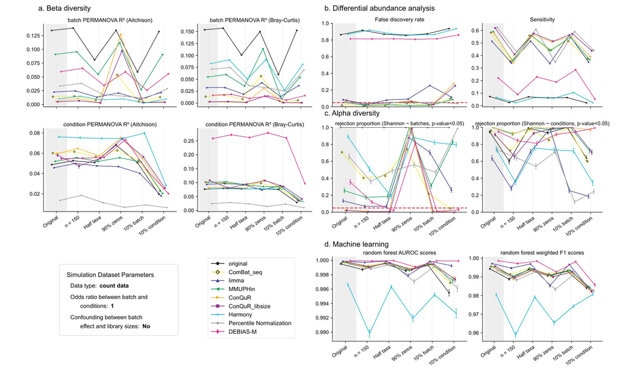

Figure 3. Means and 95% confidence intervals over 1,000 replicates. Increasing zero inflation to 90% weakened batch effect removal (ConQuR's Aitchison batch R² rose from 0.006 to 0.128); batch imbalance increased limma's FDR to 0.25, and condition imbalance increased ConQuR's to 0.28.

8

## Supplemental Figure 5: runtime

Median runtime of each integration strategy across replicates, and one run per real-world dataset.

```
python3 benchmark/figures/runtime_aggregate.py count no 1 runtime
python3 benchmark/figures/supp_runtime_plot.py runtime figures
```

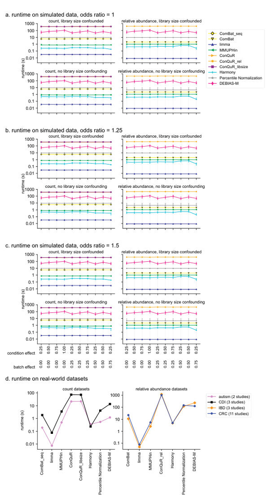

Runtimes differed by several orders of magnitude, from a fraction of a second for limma to about 20 minutes for the ConQuR family on the largest real-world datasets.

9

## Figures 4–5: real-world studies

For real-world studies there is no ground truth, and each dataset is evaluated once. MOSAIC saves PCoA plots and a table of metrics for each dataset, and a second script compares the integration strategies across datasets.

```
python3 benchmark/evaluate.py -o 4 --config my_config.yml
python3 benchmark/evaluate_alt_rw_plots.py --succinct
```

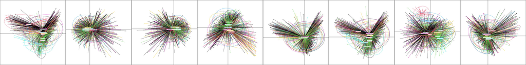

CRC (11 studies), colored by study. Scroll sideways on small screens.

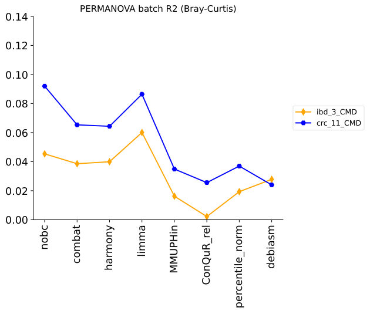

Batch PERMANOVA R², IBD and CRC.

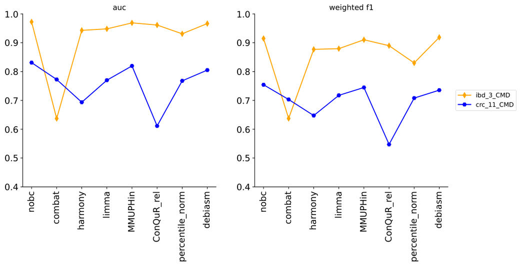

Disease-status prediction, IBD and CRC.

10

## Supplemental Tables 3, 5 and 6: literature-based evaluation

Without ground truth, MOSAIC uses the published literature as an exploratory proxy. Each differentially abundant taxon is searched in PubTator3 together with disease-specific key terms, listed under `pubtator_key_terms` in the dataset’s config (at least five). A taxon is strongly relevant if it is co-mentioned with all five terms in at least one publication, or with at least three terms in at least ten publications each.

```
bash pubtator/run_pubtator_keyterms.sh
python3 pubtator/pubtator_relevance_tables.py
python3 pubtator/pubtator_sensitivity.py
```

| CRC | Differentially abundant | Strongly relevant | Share |
| --- | --- | --- | --- |
| Uncorrected | 18 | 13 | 72% |
| Percentile Normalization | 41 | 35 | 85% |
| ConQuR-rel | 77 | 44 | 57% |
| DEBIAS-M | 82 | 42 | 51% |
| limma | 263 | 90 | 34% |

Strategies that identified many taxa had a lower proportion of strongly relevant taxa, so the number and the proportion should be read together.